# **Neural Networks Project Solution**

# **PART A**

• DOMAIN: Electronics and Telecommunication

• CONTEXT: A communications equipment manufacturing company has a product which is responsible for emitting informative signals. Company wants to build a machine learning model which can help the company to predict the equipment’s signal quality using various parameters.

• DATA DESCRIPTION: The data set contains information on various signal tests performed:

1. Parameters: Various measurable signal parameters.
2. Signal_Quality: Final signal strength or quality

• PROJECT OBJECTIVE: To build a classifier which can use the given parameters to determine the signal strength or quality.

```python
!pip3 install tensorflow
```

### **1. Data import and Understanding**

**1A. Read the ‘Signals.csv’ as DataFrame and import required libraries.**

```python
# Import all the necessary libraries.
import pandas as pd
import numpy as np
from sklearn.model_selection import train_test_split
from sklearn.preprocessing import LabelEncoder, OneHotEncoder
from sklearn.metrics import classification_report
from sklearn import model_selection
from sklearn.compose import ColumnTransformer
import matplotlib.pyplot as plt
import seaborn as sns
from sklearn.impute import SimpleImputer
import warnings
from sklearn.metrics import confusion_matrix
from sklearn.pipeline import Pipeline
from sklearn.model_selection import GridSearchCV
from sklearn.model_selection import RandomizedSearchCV
import tensorflow as tf
import random
random.seed(1)
np.random.seed(1)
tf.random.set_seed(1)
warnings.filterwarnings("ignore")
from keras import losses
from keras import optimizers
from keras import Sequential
from keras.layers import Dense
from keras import backend
from keras.layers import BatchNormalization
from keras.layers import Dropout
```

```python
df_main = pd.read_csv('Part-+1%2C2%263+-+Signal.csv')
```

```python
df_main.head()
```

|  | Parameter 1 | Parameter 2 | Parameter 3 | Parameter 4 | Parameter 5 | Parameter 6 | Parameter 7 | Parameter 8 | Parameter 9 | Parameter 10 | Parameter 11 | Signal_Strength |
| --- | --- | --- | --- | --- | --- | --- | --- | --- | --- | --- | --- | --- |
| 0 | 7.4 | 0.70 | 0.00 | 1.9 | 0.076 | 11.0 | 34.0 | 0.9978 | 3.51 | 0.56 | 9.4 | 5 |
| 1 | 7.8 | 0.88 | 0.00 | 2.6 | 0.098 | 25.0 | 67.0 | 0.9968 | 3.20 | 0.68 | 9.8 | 5 |
| 2 | 7.8 | 0.76 | 0.04 | 2.3 | 0.092 | 15.0 | 54.0 | 0.9970 | 3.26 | 0.65 | 9.8 | 5 |
| 3 | 11.2 | 0.28 | 0.56 | 1.9 | 0.075 | 17.0 | 60.0 | 0.9980 | 3.16 | 0.58 | 9.8 | 6 |
| 4 | 7.4 | 0.70 | 0.00 | 1.9 | 0.076 | 11.0 | 34.0 | 0.9978 | 3.51 | 0.56 | 9.4 | 5 |

```python
df_main.tail()
```

|  | Parameter 1 | Parameter 2 | Parameter 3 | Parameter 4 | Parameter 5 | Parameter 6 | Parameter 7 | Parameter 8 | Parameter 9 | Parameter 10 | Parameter 11 | Signal_Strength |
| --- | --- | --- | --- | --- | --- | --- | --- | --- | --- | --- | --- | --- |
| 1594 | 6.2 | 0.600 | 0.08 | 2.0 | 0.090 | 32.0 | 44.0 | 0.99490 | 3.45 | 0.58 | 10.5 | 5 |
| 1595 | 5.9 | 0.550 | 0.10 | 2.2 | 0.062 | 39.0 | 51.0 | 0.99512 | 3.52 | 0.76 | 11.2 | 6 |
| 1596 | 6.3 | 0.510 | 0.13 | 2.3 | 0.076 | 29.0 | 40.0 | 0.99574 | 3.42 | 0.75 | 11.0 | 6 |
| 1597 | 5.9 | 0.645 | 0.12 | 2.0 | 0.075 | 32.0 | 44.0 | 0.99547 | 3.57 | 0.71 | 10.2 | 5 |
| 1598 | 6.0 | 0.310 | 0.47 | 3.6 | 0.067 | 18.0 | 42.0 | 0.99549 | 3.39 | 0.66 | 11.0 | 6 |

```python
df_main.info()
```

```
<class 'pandas.core.frame.DataFrame'>
RangeIndex: 1599 entries, 0 to 1598
Data columns (total 12 columns):
 #   Column           Non-Null Count  Dtype
---  ------           --------------  -----
 0   Parameter 1      1599 non-null   float64
 1   Parameter 2      1599 non-null   float64
 2   Parameter 3      1599 non-null   float64
 3   Parameter 4      1599 non-null   float64
 4   Parameter 5      1599 non-null   float64
 5   Parameter 6      1599 non-null   float64
 6   Parameter 7      1599 non-null   float64
 7   Parameter 8      1599 non-null   float64
 8   Parameter 9      1599 non-null   float64
 9   Parameter 10     1599 non-null   float64
 10  Parameter 11     1599 non-null   float64
 11  Signal_Strength  1599 non-null   int64
dtypes: float64(11), int64(1)
memory usage: 150.0 KB
```

- There are 1599 observations and 12 columns in the data.
- All columns are of numerical type.
- 11 columns are of the float datatype and 1 column is integer.

```python
# Checking the number of rows and columns in the data
df_main.shape
```

```
(1599, 12)
```

- The dataset has 1599 rows and 12 columns.

**1B. Check for missing values and print percentage for each attribute.**

```python
# Let's check for missing values in the data
round((df_main.isnull().sum()/len(df_main))*100, 2)
```

```
Parameter 1        0.0
Parameter 2        0.0
Parameter 3        0.0
Parameter 4        0.0
Parameter 5        0.0
Parameter 6        0.0
Parameter 7        0.0
Parameter 8        0.0
Parameter 9        0.0
Parameter 10       0.0
Parameter 11       0.0
Signal_Strength    0.0
dtype: float64
```

- No Missing values in the dataset

**1C. Check for presence of duplicate records in the dataset and impute with appropriate method.**

```python
# Count how many duplicates are present in the dataframe
df_main.duplicated().sum()
```

```
240
```

```python
# Drop the duplicate rows
df_main.drop_duplicates(inplace=True)
```

```python
# Verify if all duplicates have been removed.
df_main.duplicated().sum()
```

```
0
```

**1D. Visualise distribution of the target variable.**

```python
for i in df_main.describe().columns:
    print("Unique values in", i, "are :")
    print(df_main[i].value_counts())
    print("*" * 50)
```

```
Unique values in Parameter 1 are :
7.2     49
7.8     48
7.1     46
7.0     44
7.5     42
        ..
13.8     1
13.4     1
4.7      1
15.0     1
5.5      1
Name: Parameter 1, Length: 96, dtype: int64
Unique values in Parameter 2 are :
0.500    37
0.580    36
0.400    35
0.600    34
0.430    33
         ..
1.185     1
1.240     1
0.845     1
0.365     1
1.090     1
Name: Parameter 2, Length: 143, dtype: int64
Unique values in Parameter 3 are :
0.00    118
0.49     59
0.24     41
0.02     38
0.08     32
       ...
0.72      1
0.62      1
0.71      1
0.79      1
0.78      1
Name: Parameter 3, Length: 80, dtype: int64
Unique values in Parameter 4 are :
```

[output cut: 145 more lines]

```
            ...
8.500000       1
10.033333      1
13.500000      1
13.200000      1
10.750000      1
Name: Parameter 11, Length: 65, dtype: int64
Unique values in Signal_Strength are :
5    577
6    535
7    167
4     53
8     17
3     10
Name: Signal_Strength, dtype: int64
```

```python
df_main["Signal_Strength"].value_counts()
```

```
5    577
6    535
7    167
4     53
8     17
3     10
Name: Signal_Strength, dtype: int64
```

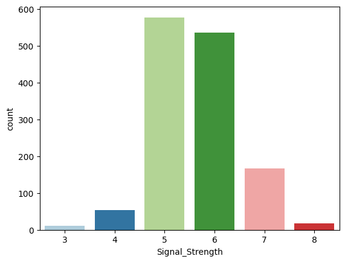

```python
sns.countplot(data=df_main,x='Signal_Strength',palette="Paired",
        order=df_main['Signal_Strength'].value_counts().index[:].sort_values());
```

**1E. Share insights from the initial data analysis (at least 2).**

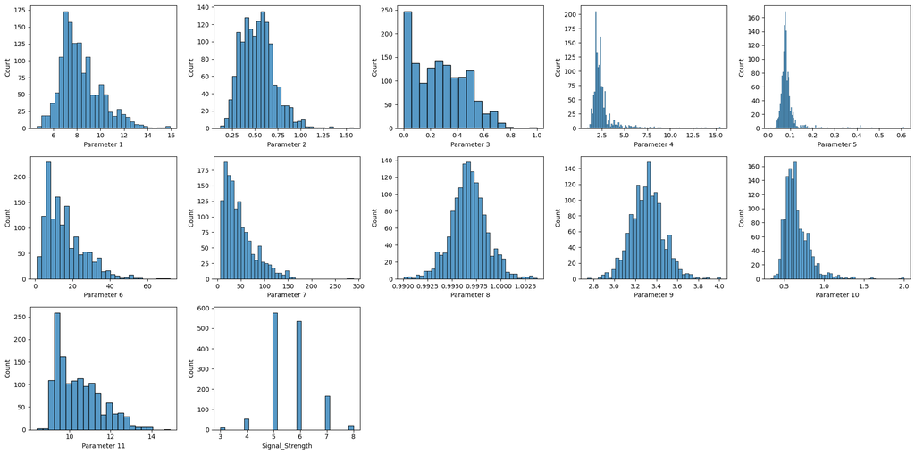

```python
n = 1
plt.figure(figsize=(20,10))
for column in df_main.describe().columns:
  plt.subplot(3, 5, n)
  n = n+1
  sns.histplot(x = df_main[column])
  plt.tight_layout()
```

```python
sns.pairplot(df_main, palette = 'bright', diag_kind='kde',  hue = 'Signal_Strength')
plt.show()
```

[output not shown]

```
Output hidden; open in https://colab.research.google.com to view.
```

### **2. Data preprocessing**

**2A. Split the data into X & Y.**

```python
## Separating Independent and Dependent Columns
X = df_main.drop(['Signal_Strength'],axis=1)
Y = df_main[['Signal_Strength']]
```

**2B. Split the data into train & test with 70:30 proportion.**

```python
# Splitting the dataset into the Training and Testing set.
X_train, X_test, y_train, y_test = train_test_split(X,Y, test_size = 0.3, random_state = 42,stratify = Y)
```

**2C. Print shape of all the 4 variables and verify if train and test data is in sync.**

```python
###Checking the shape of train and test sets
print(X_train.shape)
print(X_test.shape)
print(y_train.shape)
print(y_test.shape)
```

```
(951, 11)
(408, 11)
(951, 1)
(408, 1)
```

**2D. Normalise the train and test data with appropriate method.**

```python
# Standardization of train data only
from sklearn.preprocessing import StandardScaler

# define standard scaler
scaler = StandardScaler()

# transform train data
X_train_scaled = scaler.fit_transform(X_train)
X_test_scaled  = scaler.transform(X_test)
```

**2E. Transform Labels into format acceptable by Neural Network**

```python
y_train['Signal_Strength'] = y_train['Signal_Strength'].map({3:0, 4:1, 5:2, 6:3, 7:4, 8:5})
y_test['Signal_Strength']  = y_test['Signal_Strength'].map({3:0, 4:1, 5:2, 6:3, 7:4, 8:5})
```

```python
# Convert to "one-hot" vectors using the to_categorical function
from keras.utils import to_categorical
y_train_cat = to_categorical(y_train)
y_test_cat  = to_categorical(y_test)
```

```python
# Labels after applying the function
# Training set labels
print(X_train_scaled.shape)
print(X_test_scaled.shape)
print(y_train_cat.shape)
print(y_test_cat.shape)
```

```
(951, 11)
(408, 11)
(951, 6)
(408, 6)
```

### **3. Model Training & Evaluation using Neural Network**

```python
backend.clear_session()
#Fixing the seed for random number generators so that we can ensure we receive the same output everytime
np.random.seed(42)
import random
random.seed(42)
tf.random.set_seed(42)
```

```python
# Capturing learning history per epoch
def print_report(history, model):

  loss, accuracy = model.evaluate(X_test_scaled, y_test_cat, verbose=False)

  hist  = pd.DataFrame(history.history)
  hist['epoch'] = history.epoch

  # Plotting loss at different epochs
  plt.plot(hist['loss'])
  plt.plot(hist['val_loss'])
  plt.legend(("training","validation"), loc = 'best')
  plt.title('model loss')
  plt.xlabel("Number of Epochs")
  plt.ylabel("Learning Loss")
  plt.show()

  print('--------------------------------------')

  # Plotting accuracy at different epochs
  plt.plot(hist['accuracy'])
  plt.plot(hist['val_accuracy'])
  plt.title('model accuracy')
  plt.ylabel('Accuracy')
  plt.xlabel('Number of Epochs')
  plt.legend(['training', 'validation'], loc='best')
  plt.show()

  # predicting the class on test data
  y_pred = model.predict(X_test_scaled)

  # As our outputs are probabilities so we will try to get the output class from these probablities by getting the maximum value
  y_pred_final=[]
  for i in y_pred:
    y_pred_final.append(np.argmax(i))

  # Classification Report
  print('\n\nClassification Report')
  print('--------------------------------------')
  print(classification_report(y_test,y_pred_final))


  # COnfusion Matrix
  print('\n\nConfusion Matrix')
  print('--------------------------------------')
  cm=confusion_matrix(y_test,y_pred_final)
  plt.figure(figsize=(10,7))
  sns.heatmap(cm,annot=True,fmt='d')
  plt.xlabel('Predicted')
  plt.ylabel('Truth')
  plt.show()
```

**3A. Design a Neural Network to train a classifier.**

**3B. Train the classifier using previously designed Architecture**

**3C. Plot 2 separate visuals.**

i. Training Loss and Validation Loss

ii. Training Accuracy and Validation Accuracy

**MODEL 1 - Simple Neural Network**

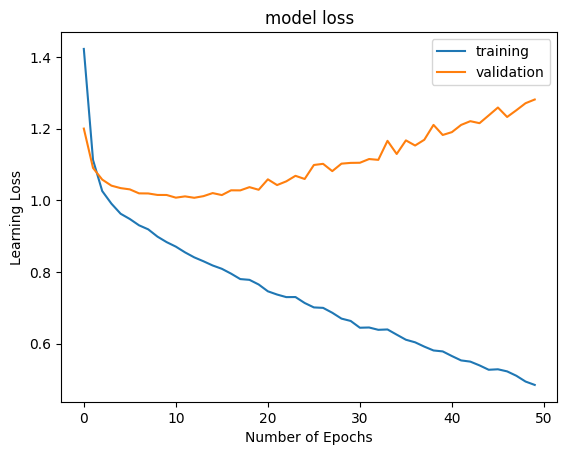

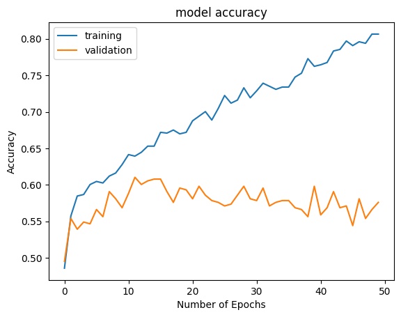

```
Classification Report
--------------------------------------
              precision    recall  f1-score   support

           0       0.00      0.00      0.00         3
           1       0.00      0.00      0.00        16
           2       0.65      0.73      0.68       173
           3       0.55      0.52      0.53       161
           4       0.50      0.52      0.51        50
           5       0.00      0.00      0.00         5

    accuracy                           0.58       408
   macro avg       0.28      0.29      0.29       408
weighted avg       0.55      0.58      0.56       408



Confusion Matrix
--------------------------------------
```

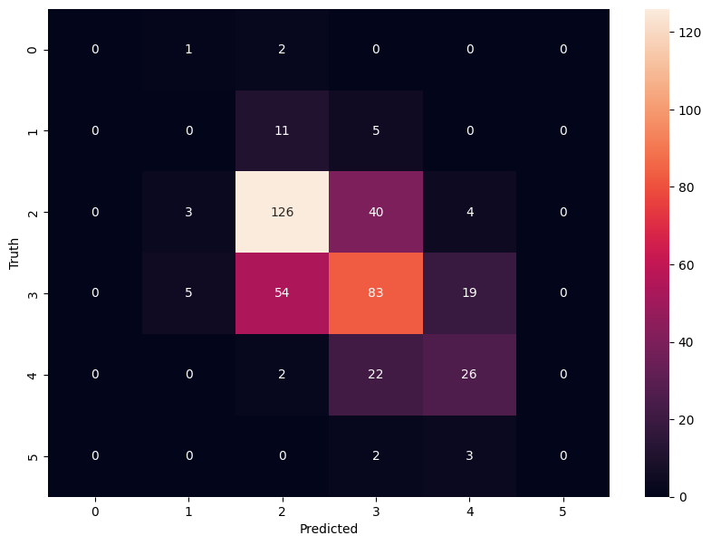

```python
num_classes = 6
# create model
model_1 = Sequential()
model_1.add(Dense(64, activation='relu', input_dim = 11))
model_1.add(Dense(64, activation='relu'))
model_1.add(Dense(32, activation='relu'))
model_1.add(Dense(num_classes, activation='softmax')) ### For multiclass classification Softmax is used

# Compile the model
model_1.compile(optimizer='adam', loss='categorical_crossentropy', metrics=['accuracy'])

history = model_1.fit(X_train_scaled, y_train_cat, validation_data=(X_test_scaled, y_test_cat), epochs=50, batch_size = 32, verbose = 0)

print_report(history, model_1)
```

**Observation:**

- The accuracy is at 58%.
- No classification in labels 0 , 1 and 5 which is mostly because of less data available in those classes.
- The performance of test data is poor probably due to overfit train data with basic NN model.
- Now we will try to observe how Batch Normalization and Dropout can be used in our model.

**MODEL 2 - Batch Normalization and Dropout**

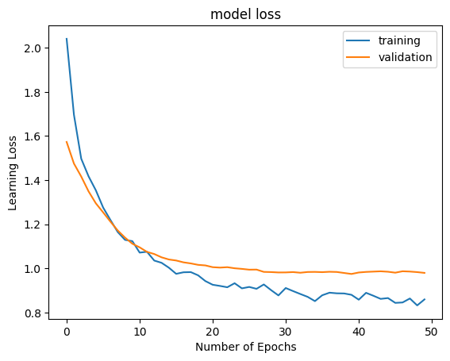

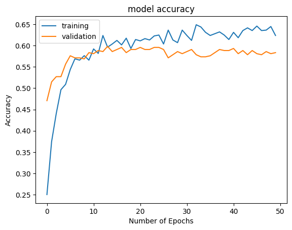

```
Classification Report
--------------------------------------
              precision    recall  f1-score   support

           0       0.00      0.00      0.00         3
           1       0.33      0.12      0.18        16
           2       0.66      0.70      0.68       173
           3       0.54      0.61      0.57       161
           4       0.46      0.34      0.39        50
           5       0.00      0.00      0.00         5

    accuracy                           0.58       408
   macro avg       0.33      0.30      0.30       408
weighted avg       0.56      0.58      0.57       408



Confusion Matrix
--------------------------------------
```

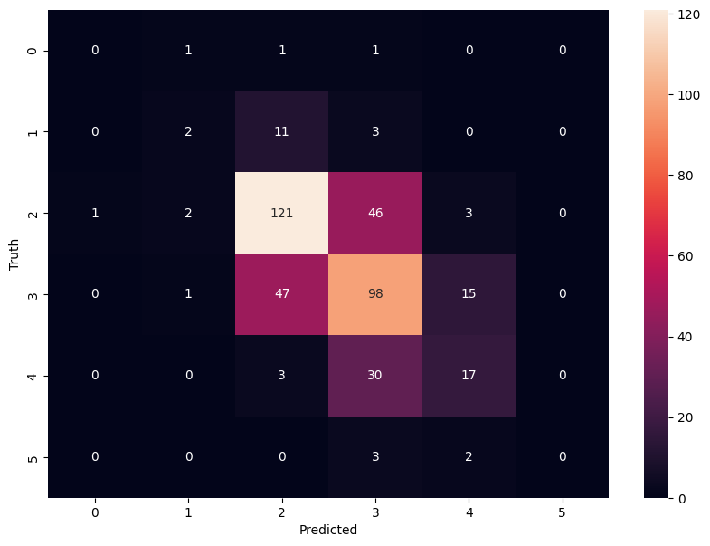

```python
num_classes = 6

# create model
model_2 = Sequential()

model_2.add(Dense(64, activation='relu',kernel_initializer='he_uniform', input_dim = 11)) ###Multiple Dense units with Relu activation
model_2.add(BatchNormalization())
model_2.add(Dropout(0.2))
model_2.add(Dense(64, activation='relu',kernel_initializer='he_uniform'))
model_2.add(BatchNormalization())
model_2.add(Dropout(0.2))
model_2.add(Dense(32, activation='relu',kernel_initializer='he_uniform'))
model_2.add(BatchNormalization())
model_2.add(Dropout(0.05))
model_2.add(Dense(num_classes, activation='softmax')) ### For multiclass classification Softmax is used

# Compile the model
adam = optimizers.Adam(lr=1e-3)
model_2.compile(optimizer = adam, loss=losses.categorical_crossentropy, metrics=['accuracy'])

history = model_2.fit(X_train_scaled, y_train_cat, validation_data=(X_test_scaled, y_test_cat), epochs=50, batch_size=32, verbose=0)

print_report(history, model_2)
```

**Observation:**

**MODEL 3 - Random Search CV**

```python
def create_model(lr, batch_size, num_classes):
    # create model
    model = Sequential()
    model.add(Dense(64, activation='relu',kernel_initializer='he_uniform', input_dim = 11)) ###Multiple Dense units with Relu activation
    model.add(BatchNormalization())
    model.add(Dropout(0.2))
    model.add(Dense(64, activation='relu',kernel_initializer='he_uniform'))
    model.add(BatchNormalization())
    model.add(Dropout(0.2))
    model.add(Dense(32, activation='relu',kernel_initializer='he_uniform'))
    model.add(BatchNormalization())
    model.add(Dropout(0.05))
    model.add(Dense(num_classes, activation='softmax')) ### For multiclass classification Softmax is used

    # Compile the model
    adam = optimizers.Adam(lr=lr)
    model.compile(optimizer = 'adam', loss = 'categorical_crossentropy', metrics=['accuracy'])

    return model
```

```
Fitting 3 folds for each of 9 candidates, totalling 27 fits
Best: 0.253417 using {'lr': 0.01, 'batch_size': 32}
```

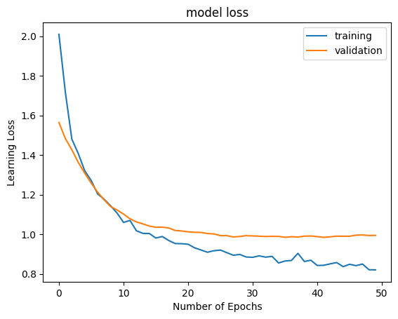

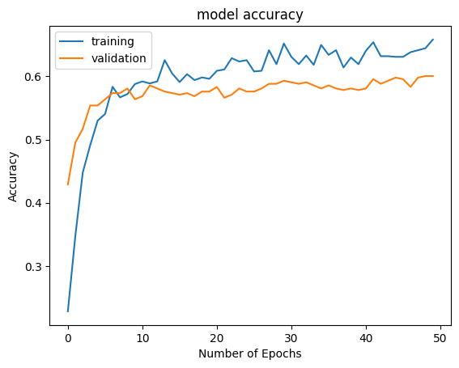

```
Classification Report
--------------------------------------
              precision    recall  f1-score   support

           0       0.00      0.00      0.00         3
           1       0.00      0.00      0.00        16
           2       0.66      0.69      0.68       173
           3       0.57      0.64      0.60       161
           4       0.54      0.44      0.48        50
           5       0.00      0.00      0.00         5

    accuracy                           0.60       408
   macro avg       0.29      0.30      0.29       408
weighted avg       0.57      0.60      0.58       408



Confusion Matrix
--------------------------------------
```

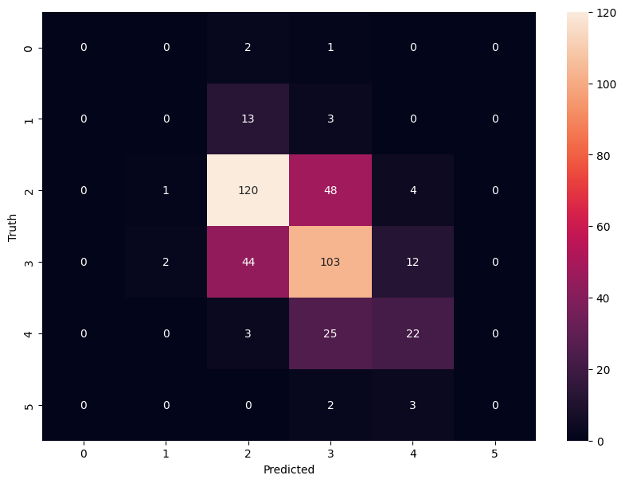

```python
from keras.wrappers.scikit_learn import KerasClassifier

# define the grid search parameters
param = {
    'batch_size':[32, 64, 128],
    "lr":[0.01,0.1,0.001]
    }


random = RandomizedSearchCV(estimator = KerasClassifier(build_fn=create_model,
                          num_classes = 6),
                           verbose = 1,
                           cv = 3,
                           param_distributions = param,
                           n_jobs=-1)

random_result = random.fit(X_train_scaled, y_train_cat, validation_split=0.2)

# Summarize results
print("Best: %f using %s" % (random_result.best_score_, random_result.best_params_))

# Create model with best params from random search
model_3 = create_model(lr=random_result.best_params_['lr'], batch_size = random_result.best_params_['batch_size'], num_classes = 6)

history = model_3.fit(X_train_scaled, y_train_cat, validation_data=(X_test_scaled, y_test_cat), epochs=50, batch_size=random_result.best_params_['batch_size'], verbose=1)

print_report(history, model_3)
```

**3D. Design new architecture/update existing architecture in attempt to improve the performance of the model.**

**3E. Plot visuals as in Q3.C and share insights about difference observed in both the models.**

**MODEL 4 - with classes grouped**

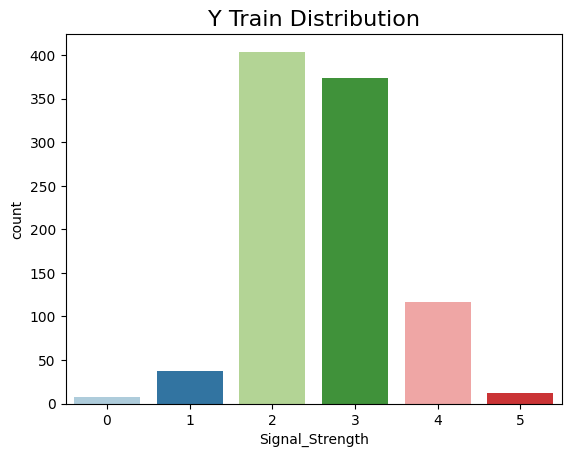

```python
sns.countplot(data=y_train,x='Signal_Strength',palette="Paired",
        order=y_train['Signal_Strength'].value_counts().index[:].sort_values());
plt.title('Y Train Distribution', fontsize = 16);
```

- From above graph, the num of observations for Signal strength 0, 1, 4, 5 are very less. It may be better to combine classes (0, 1), (2,3) and (4,5).

```python
y_train['Signal_Strength'] = y_train['Signal_Strength'].map({0:0, 1:0, 2:1, 3:1, 4:2, 5:2})
y_test['Signal_Strength']  = y_test['Signal_Strength'].map({0:0, 1:0, 2:1, 3:1, 4:2, 5:2})
```

```python
y_train['Signal_Strength'].value_counts()
```

```
1    778
2    129
0     44
Name: Signal_Strength, dtype: int64
```

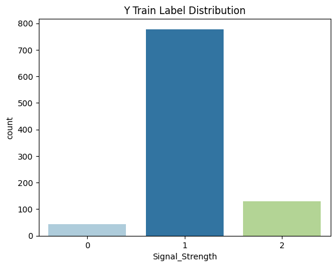

```python
sns.countplot(data=y_train,x='Signal_Strength',palette="Paired",
        order=y_train['Signal_Strength'].value_counts().index[:].sort_values());
plt.title('Y Train Label Distribution', fontsize = 12);
```

- The target class is highly imbalanced and may impact our final analysis. More data needs to be collected in the classes 0, 2.

```python
# Convert to "one-hot" vectors using the to_categorical function
from keras.utils import to_categorical
y_train_cat = to_categorical(y_train)
y_test_cat  = to_categorical(y_test)
```

```python
# Labels after applying the function
# Training set labels
print(X_train_scaled.shape)
print(X_test_scaled.shape)
print(y_train_cat.shape)
print(y_test_cat.shape)
```

```
(951, 11)
(408, 11)
(951, 3)
(408, 3)
```

```
Fitting 3 folds for each of 9 candidates, totalling 27 fits
Best: 0.541535 using {'lr': 0.01, 'batch_size': 128}
```

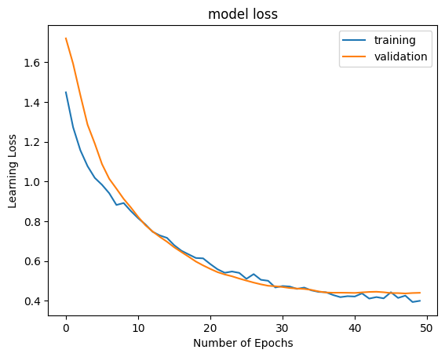

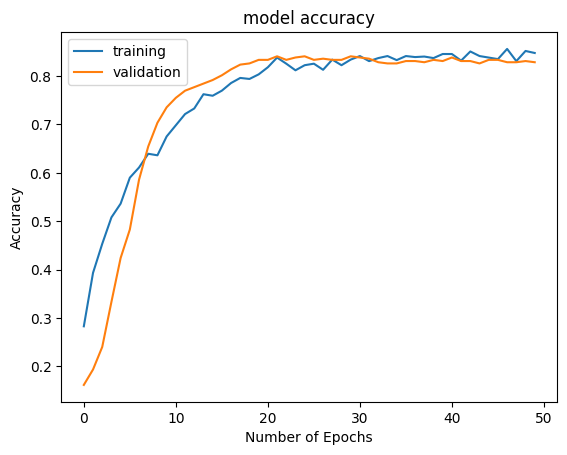

```
Classification Report
--------------------------------------
              precision    recall  f1-score   support

           0       0.00      0.00      0.00        19
           1       0.87      0.93      0.90       334
           2       0.57      0.53      0.55        55

    accuracy                           0.83       408
   macro avg       0.48      0.48      0.48       408
weighted avg       0.79      0.83      0.81       408



Confusion Matrix
--------------------------------------
```

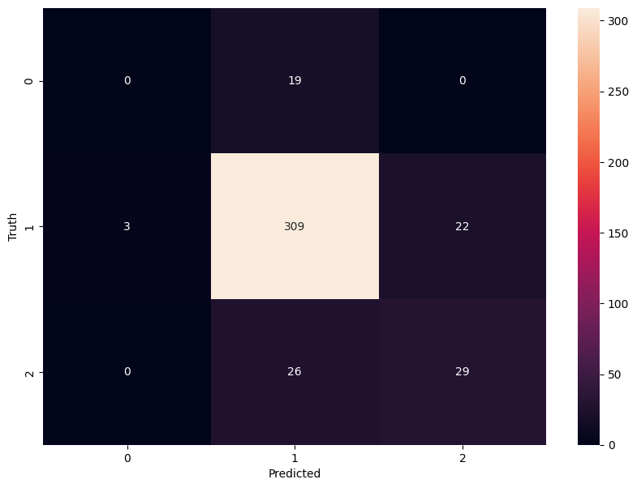

```python
# define the grid search parameters
param = {
    'batch_size':[32, 64, 128],
    "lr":[0.01,0.1,0.001]
    }

random = RandomizedSearchCV(estimator = KerasClassifier(build_fn=create_model, num_classes = 3),
                           verbose = 1, cv = 3, param_distributions = param, n_jobs=-1)

random_result = random.fit(X_train_scaled, y_train_cat, validation_split=0.2)

# Summarize results
print("Best: %f using %s" % (random_result.best_score_, random_result.best_params_))

# Create model with best params from random search
model_4 = create_model(lr=random_result.best_params_['lr'], batch_size = random_result.best_params_['batch_size'], num_classes = 3)

history = model_4.fit(X_train_scaled, y_train_cat, validation_data=(X_test_scaled, y_test_cat), epochs=50, batch_size=random_result.best_params_['batch_size'], verbose=0)

print_report(history, model_4)
```

# **PART B**

• DOMAIN: Autonomous Vehicles

• CONTEXT: A Recognising multi-digit numbers in photographs captured at street level is an important component of modern-day map making. A classic example of a corpus of such street-level photographs is Google’s Street View imagery composed of hundreds of millions of geo-located 360-degree panoramic images. The ability to automatically transcribe an address number from a geo-located patch of pixels and associate the transcribed number with a known street address helps pinpoint, with a high degree of accuracy, the location of the building it represents. More broadly, recognising numbers in photographs is a problem of interest to the optical character recognition community. While OCR on constrained domains like document processing is well studied, arbitrary multi-character text recognition in photographs is still highly challenging. This difficulty arises due to the wide variability in the visual appearance of text in the wild on account of a large range of fonts, colours, styles, orientations, and character arrangements. The recognition problem is further complicated by environmental factors such as lighting, shadows, specularity, and occlusions as well as by image acquisition factors such as resolution, motion, and focus blurs. In this project, we will use the dataset with images centred around a single digit (many of the images do contain some distractors at the sides). Although we are taking a sample of the data which is simpler, it is more complex than MNIST because of the distractors.

• DATA DESCRIPTION: The SVHN is a real-world image dataset for developing machine learning and object recognition algorithms with the minimal requirement on data formatting but comes from a significantly harder, unsolved, real-world problem (recognising digits and numbers in natural scene images). SVHN is obtained from house numbers in Google Street View images. Where the labels for each of this image are the prominent number in that image i.e. 2,6,7 and 4 respectively. The dataset has been provided in the form of h5py files. You can read about this file format here: https://docs.h5py.org/en/stable/ Acknowledgement: Yuval Netzer, Tao Wang, Adam Coates, Alessandro Bissacco, Bo Wu, Andrew Y. Ng Reading Digits in Natural Images with Unsupervised Feature Learning NIPS Workshop on Deep Learning and Unsupervised Feature Learning 2011. PDF http://ufldl.stanford.edu/housenumbers as the URL for this site.

• PROJECT OBJECTIVE: To build a digit classifier on the SVHN (Street View Housing Number) dataset.

**1. Data Import and Exploration**

**1A. Read the .h5 file and assign to a variable.**

```python
import h5py

hf = h5py.File('Autonomous_Vehicles_SVHN_single_grey1.h5', 'r')
```

**1B. Print all the keys from the .h5 file.**

```python
hf.keys()
```

```
<KeysViewHDF5 ['X_test', 'X_train', 'X_val', 'y_test', 'y_train', 'y_val']>
```

**1C. Split the data into X_train, X_test, Y_train, Y_test**

```python
# Load the training, validation and test sets
X_train = hf['X_train'][:]
y_train = hf['y_train'][:]
X_valid = hf['X_val'][:]
y_valid = hf['y_val'][:]
X_test  = hf['X_test'][:]
y_test  = hf['y_test'][:]

# Close this file
hf.close()
```

**2. Data Visualisation and preprocessing**

**2A. Print shape of all the 4 data split into x, y, train, test to verify if x & y is in sync.**

```python
print('Shape of Training set', X_train.shape, y_train.shape)
print('Shape of Validation set', X_valid.shape, y_valid.shape)
print('Shape of Test set', X_test.shape, y_test.shape)
```

```
Shape of Training set (42000, 32, 32) (42000,)
Shape of Validation set (60000, 32, 32) (60000,)
Shape of Test set (18000, 32, 32) (18000,)
```

- The training data has 42000 rows with image size 32x32.
- The validation data has 60000 rows with image size 32x32.
- The test data has 18000 rows with image size 32x32.
- All x, y data are in sync.

**2B. Visualise first 10 images in train data and print its corresponding labels.**

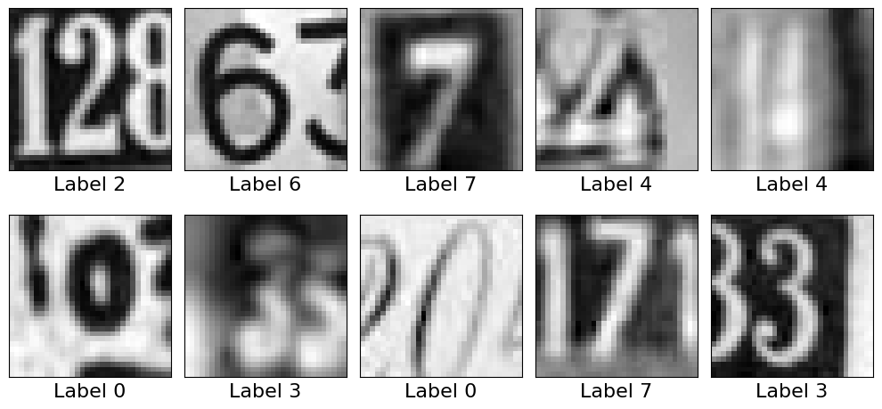

```python
n = 1
plt.figure(figsize=(10,5))

for i in range(10):
  plt.subplot(2, 5, n)
  n = n+1
  plt.imshow(np.array(X_train[i], dtype='float').reshape((32,32)), cmap='gray')
  plt.xlabel('Label %d'% y_train[i], fontsize=16)
  plt.ylabel('')
  plt.xticks([], [])
  plt.yticks([], [])

plt.tight_layout()
```

**2C. Reshape all the images with appropriate shape update the data in same variable.**

```python
# Flatten the images
image_vector_size = 32*32
X_train = X_train.reshape((X_train.shape[0], image_vector_size))
X_valid = X_valid.reshape((X_valid.shape[0], image_vector_size))
X_test = X_test.reshape((X_test.shape[0], image_vector_size))
print('Shape of Training set', X_train.shape, y_train.shape)
print('Shape of Validation set', X_valid.shape, y_valid.shape)
print('Shape of Test set', X_test.shape, y_test.shape)
```

```
Shape of Training set (42000, 1024) (42000,)
Shape of Validation set (60000, 1024) (60000,)
Shape of Test set (18000, 1024) (18000,)
```

**2D. Normalise the images i.e. Normalise the pixel values.**

```python
# normalize inputs from 0-255 to 0-1
X_train /= 255.0
X_valid /= 255.0
X_test /= 255.0
```

**2E. Transform Labels into format acceptable by Neural Network**

```python
from tensorflow.keras.utils import to_categorical
# Convert to "one-hot" vectors using the to_categorical function
num_classes = 10
y_train_cat = to_categorical(y_train)
y_valid_cat = to_categorical(y_valid)
y_test_cat = to_categorical(y_test)
```

```python
print("First 5 training lables as one-hot encoded vectors:\n", y_train_cat[:5])
```

```
First 5 training lables as one-hot encoded vectors:
 [[0. 0. 1. 0. 0. 0. 0. 0. 0. 0.]
 [0. 0. 0. 0. 0. 0. 1. 0. 0. 0.]
 [0. 0. 0. 0. 0. 0. 0. 1. 0. 0.]
 [0. 0. 0. 0. 1. 0. 0. 0. 0. 0.]
 [0. 0. 0. 0. 1. 0. 0. 0. 0. 0.]]
```

**2F. Print total Number of classes in the Dataset.**

```python
print('No. of Classes in y_train is %d: ' %len(np.unique(y_train)), np.unique(y_train))
print('No. of Classes in y_valid is %d: ' %len(np.unique(y_valid)), np.unique(y_valid))
print('No. of Classes in y_test  is %d: ' %len(np.unique(y_test)),  np.unique(y_test))
```

```
No. of Classes in y_train is 10:  [0 1 2 3 4 5 6 7 8 9]
No. of Classes in y_valid is 10:  [0 1 2 3 4 5 6 7 8 9]
No. of Classes in y_test  is 10:  [0 1 2 3 4 5 6 7 8 9]
```

**3. Model Training & Evaluation using Neural Network**

- 3A. Design a Neural Network to train a classifier.
- 3B. Train the classifier using previously designed Architecture (Use best suitable parameters).
- 3C. Evaluate performance of the model with appropriate metrics.
- 3D. Plot the training loss, validation loss vs number of epochs and training accuracy, validation accuracy vs number of epochs plot and write your observations on the same.

```python
# Capturing learning history per epoch
def print_hf_report(history, model):

  loss, accuracy = model.evaluate(X_test, y_test_cat, verbose=False)

  hist  = pd.DataFrame(history.history)
  hist['epoch'] = history.epoch

  # Plotting loss at different epochs
  plt.plot(hist['loss'])
  plt.plot(hist['val_loss'])
  plt.legend(("training","validation"), loc = 'best')
  plt.title('model loss')
  plt.xlabel("Number of Epochs")
  plt.ylabel("Learning Loss")
  plt.show()

  print('--------------------------------------')

  # Plotting accuracy at different epochs
  plt.plot(hist['accuracy'])
  plt.plot(hist['val_accuracy'])
  plt.title('model accuracy')
  plt.ylabel('Accuracy')
  plt.xlabel('Number of Epochs')
  plt.legend(['training', 'validation'], loc='best')
  plt.show()

  # predicting the class on test data
  y_pred = model.predict(X_test)

  # As our outputs are probabilities so we will try to get the output class from these probablities by getting the maximum value
  y_pred_final=[]
  for i in y_pred:
    y_pred_final.append(np.argmax(i))

  # Classification Report
  print('\n\nClassification Report')
  print('--------------------------------------')
  print(classification_report(y_test,y_pred_final))


  # COnfusion Matrix
  print('\n\nConfusion Matrix')
  print('--------------------------------------')
  cm=confusion_matrix(y_test,y_pred_final)
  plt.figure(figsize=(10,7))
  sns.heatmap(cm,annot=True,fmt='d')
  plt.xlabel('Predicted')
  plt.ylabel('Truth')
  plt.show()
```

**MODEL 1 - Simple Neural Network with SGD**

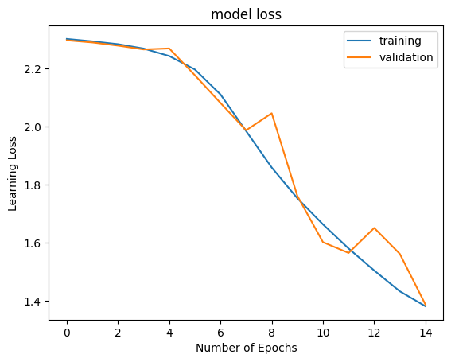

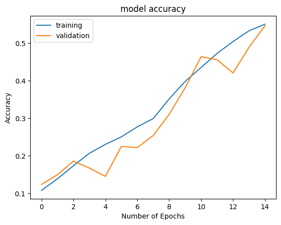

```
Classification Report
--------------------------------------
              precision    recall  f1-score   support

           0       0.37      0.82      0.51      1814
           1       0.49      0.73      0.59      1828
           2       0.82      0.45      0.58      1803
           3       0.60      0.56      0.58      1719
           4       0.64      0.75      0.69      1812
           5       0.74      0.39      0.51      1768
           6       0.48      0.69      0.57      1832
           7       0.73      0.63      0.68      1808
           8       0.49      0.24      0.32      1812
           9       0.71      0.22      0.33      1804

    accuracy                           0.55     18000
   macro avg       0.61      0.55      0.54     18000
weighted avg       0.61      0.55      0.54     18000



Confusion Matrix
--------------------------------------
```

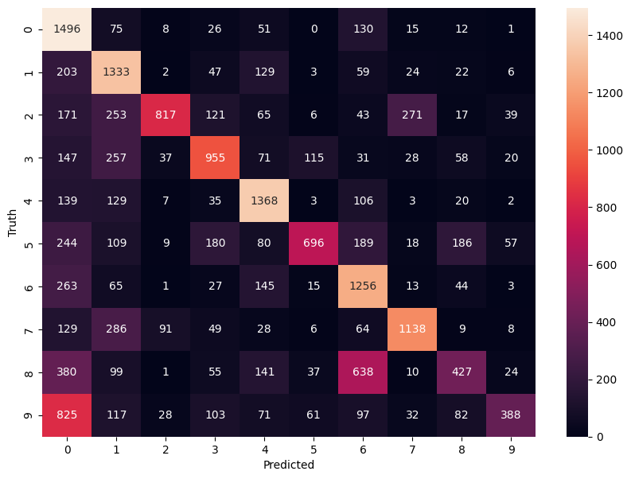

```python
num_classes = 10
image_size = 32*32

# create model
hf_model_1 = Sequential()
hf_model_1.add(Dense(256, activation='relu', input_shape=(image_size,)))
hf_model_1.add(Dense(64, activation='relu'))
hf_model_1.add(Dense(64, activation='relu'))
hf_model_1.add(Dense(32, activation='relu'))
hf_model_1.add(Dense(num_classes, activation='softmax')) ### For multiclass classification Softmax is used

# Compile the model
hf_model_1.compile(optimizer='sgd', loss='categorical_crossentropy', metrics=['accuracy'])

history = hf_model_1.fit(X_train, y_train_cat, validation_data=(X_valid, y_valid_cat), epochs=15, batch_size = 128, verbose = 0)

print_hf_report(history, hf_model_1)
```

**Observations:**

**MODEL 2 - Simple Neural Network with SGD batch normalization**

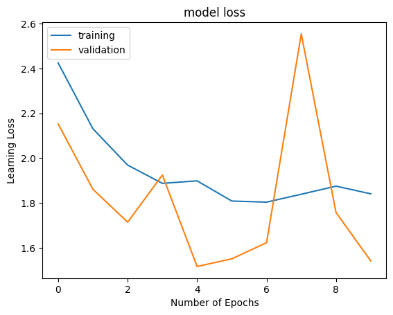

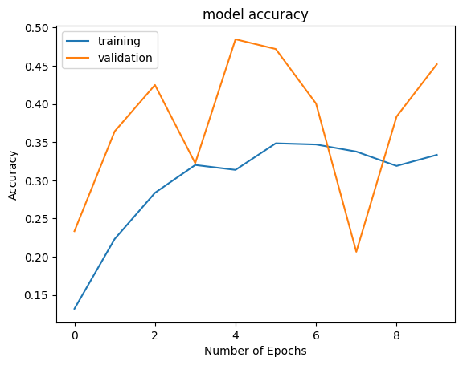

```
Classification Report
--------------------------------------
              precision    recall  f1-score   support

           0       0.44      0.46      0.45      1814
           1       0.38      0.76      0.51      1828
           2       0.44      0.28      0.34      1803
           3       0.42      0.54      0.47      1719
           4       0.65      0.70      0.67      1812
           5       0.36      0.41      0.38      1768
           6       0.60      0.50      0.55      1832
           7       0.50      0.46      0.48      1808
           8       0.31      0.14      0.19      1812
           9       0.45      0.30      0.36      1804

    accuracy                           0.45     18000
   macro avg       0.46      0.45      0.44     18000
weighted avg       0.46      0.45      0.44     18000



Confusion Matrix
--------------------------------------
```

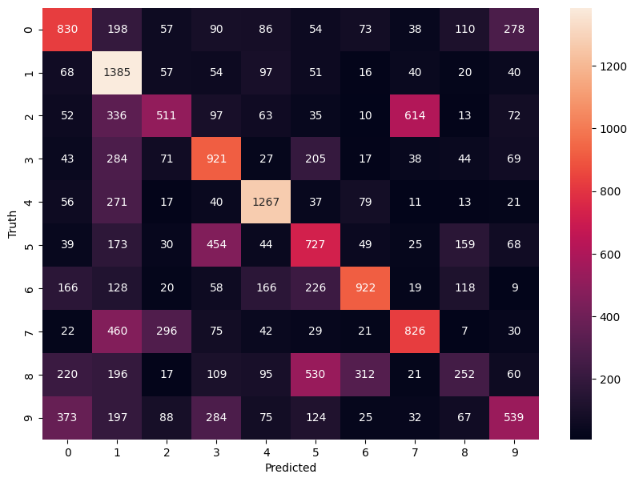

```python
num_classes = 10
image_size = 32*32

# create model
hf_model_2 = Sequential()

hf_model_2.add(Dense(256, activation='relu', input_shape=(image_size,)))
hf_model_2.add(BatchNormalization())
hf_model_2.add(Dropout(0.2))
hf_model_2.add(Dense(64, activation='relu',kernel_initializer='he_uniform'))
hf_model_2.add(BatchNormalization())
hf_model_2.add(Dropout(0.5))
hf_model_2.add(Dense(64, activation='relu',kernel_initializer='he_uniform'))
hf_model_2.add(BatchNormalization())
hf_model_2.add(Dropout(0.2))
hf_model_2.add(Dense(32, activation='relu',kernel_initializer='he_uniform'))
hf_model_2.add(BatchNormalization())
hf_model_2.add(Dropout(0.05))
hf_model_2.add(Dense(num_classes, activation='softmax')) ### For multiclass classification Softmax is used

# Compile the model
hf_model_2.compile(optimizer = 'sgd', loss=losses.categorical_crossentropy, metrics=['accuracy'])

history = hf_model_2.fit(X_train, y_train_cat, validation_data=(X_valid, y_valid_cat), epochs=10, batch_size=32, verbose=0)

print_hf_report(history, hf_model_2)
```

**Observations:**

**MODEL 3 - Simple Neural Network with SGD batch normalization - reduced layers**

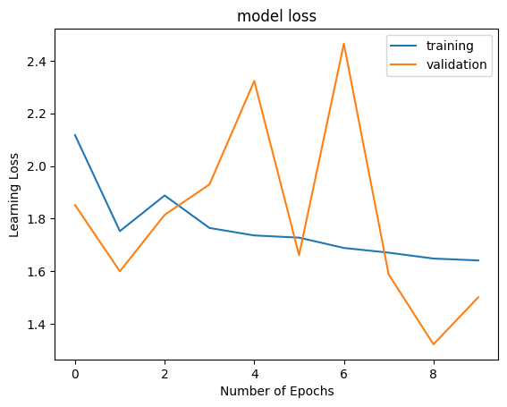

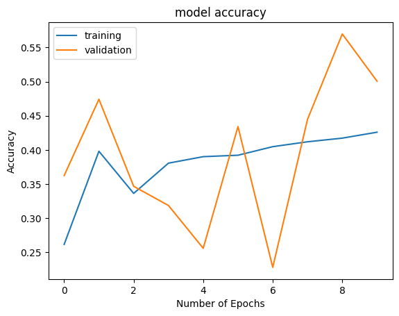

```
Classification Report
--------------------------------------
              precision    recall  f1-score   support

           0       0.52      0.42      0.47      1814
           1       0.59      0.53      0.56      1828
           2       0.54      0.39      0.45      1803
           3       0.45      0.58      0.51      1719
           4       0.50      0.77      0.60      1812
           5       0.70      0.52      0.60      1768
           6       0.52      0.57      0.54      1832
           7       0.44      0.41      0.43      1808
           8       0.37      0.52      0.43      1812
           9       0.51      0.28      0.36      1804

    accuracy                           0.50     18000
   macro avg       0.51      0.50      0.49     18000
weighted avg       0.51      0.50      0.49     18000



Confusion Matrix
--------------------------------------
```

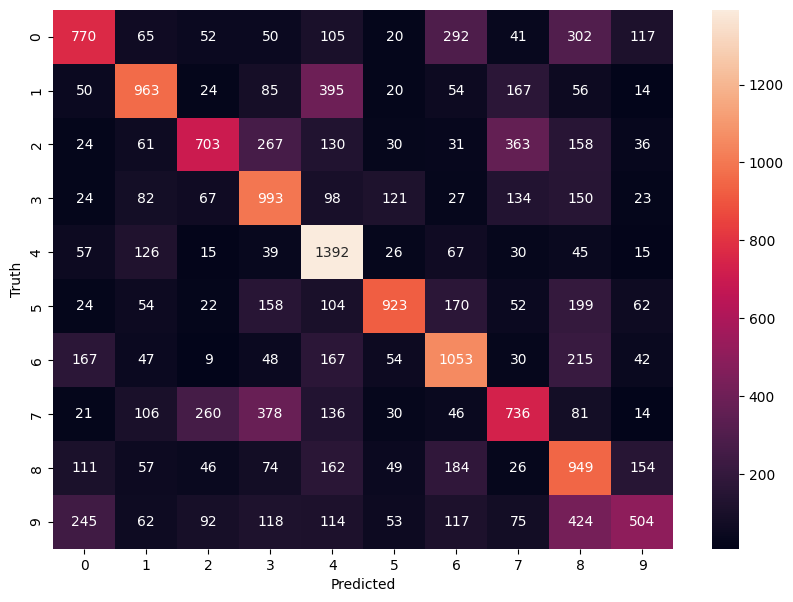

```python
num_classes = 10
image_size = 32*32

# create model
hf_model_3 = Sequential()

hf_model_3.add(Dense(256, activation='relu', input_shape=(image_size,)))
hf_model_3.add(BatchNormalization())
hf_model_3.add(Dropout(0.2))
hf_model_3.add(Dense(64, activation='relu',kernel_initializer='he_uniform'))
hf_model_3.add(BatchNormalization())
hf_model_3.add(Dropout(0.2))
hf_model_3.add(Dense(32, activation='relu',kernel_initializer='he_uniform'))
hf_model_3.add(BatchNormalization())
hf_model_3.add(Dropout(0.05))
hf_model_3.add(Dense(num_classes, activation='softmax')) ### For multiclass classification Softmax is used

# Compile the model
hf_model_3.compile(optimizer = 'sgd', loss=losses.categorical_crossentropy, metrics=['accuracy'])

history = hf_model_3.fit(X_train, y_train_cat, validation_data=(X_valid, y_valid_cat), epochs=10, batch_size=32, verbose=0)

print_hf_report(history, hf_model_3)
```

**Observations:**

- Unfortunately, there is no much difference in the model performance even with reduced layers. Let us remove dropout and try.

**MODEL 4 - SGD with learning rate .001**

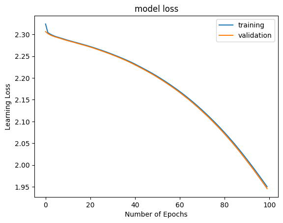

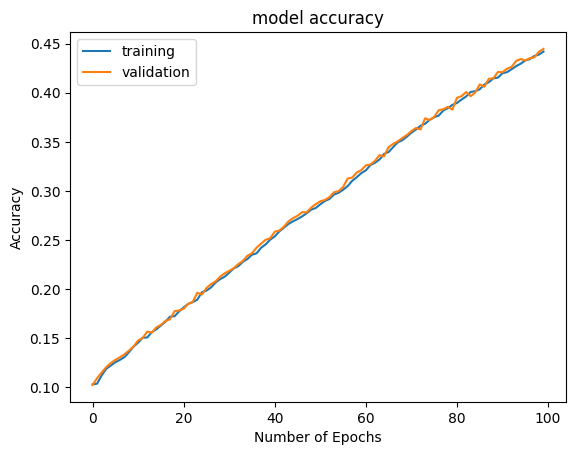

```
Classification Report
--------------------------------------
              precision    recall  f1-score   support

           0       0.40      0.59      0.48      1814
           1       0.45      0.66      0.53      1828
           2       0.45      0.40      0.42      1803
           3       0.41      0.37      0.39      1719
           4       0.49      0.68      0.57      1812
           5       0.57      0.27      0.37      1768
           6       0.39      0.29      0.34      1832
           7       0.52      0.66      0.58      1808
           8       0.32      0.14      0.19      1812
           9       0.41      0.37      0.39      1804

    accuracy                           0.44     18000
   macro avg       0.44      0.44      0.43     18000
weighted avg       0.44      0.44      0.43     18000



Confusion Matrix
--------------------------------------
```

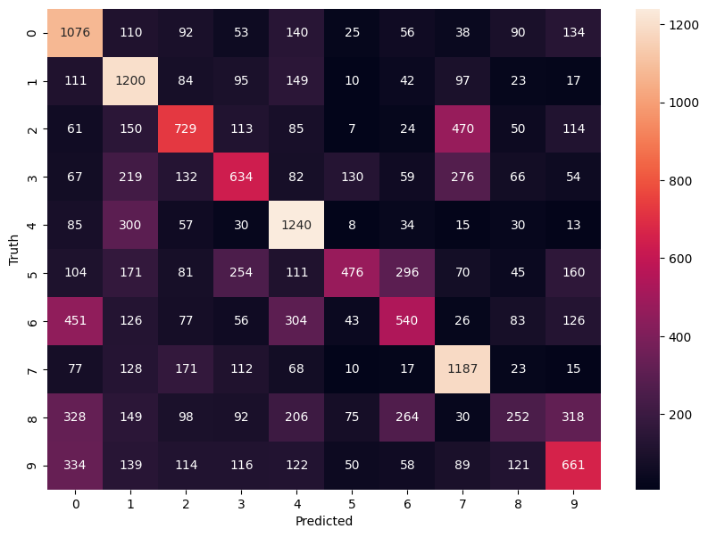

```python
# create model
hf_model_4 = Sequential()
hf_model_4.add(Dense(128 , activation='relu', input_shape = (1024, )))
hf_model_4.add(Dense(64, activation='relu'))
hf_model_4.add(Dense(10, activation = 'softmax'))

# Compile the model
sgd = optimizers.SGD(lr = 0.001)
hf_model_4.compile(optimizer = sgd, loss=losses.categorical_crossentropy, metrics=['accuracy'])

history = hf_model_4.fit(X_train, y_train_cat, validation_data=(X_valid, y_valid_cat), epochs=100, batch_size=200, verbose=0)

print_hf_report(history, hf_model_4)
```

**MODEL 5 - SGD with learning rate .01**

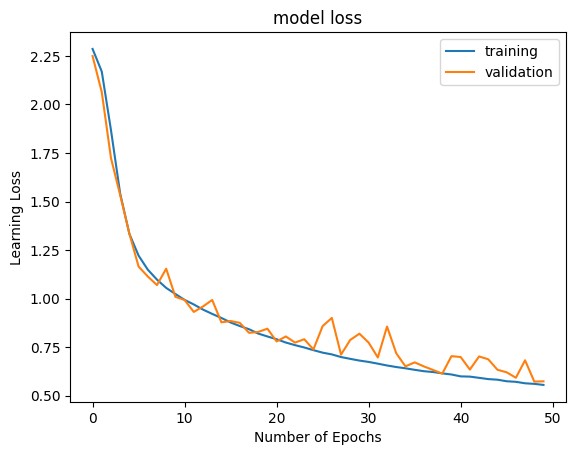

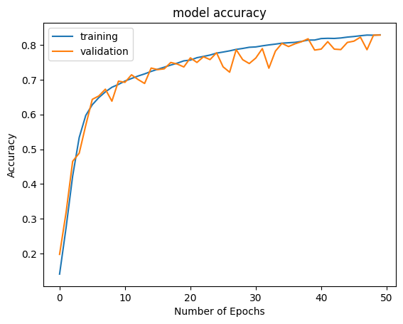

```
Classification Report
--------------------------------------
              precision    recall  f1-score   support

           0       0.86      0.85      0.85      1814
           1       0.77      0.87      0.81      1828
           2       0.85      0.81      0.83      1803
           3       0.78      0.72      0.75      1719
           4       0.85      0.84      0.84      1812
           5       0.72      0.83      0.77      1768
           6       0.80      0.81      0.81      1832
           7       0.88      0.81      0.84      1808
           8       0.71      0.79      0.75      1812
           9       0.87      0.72      0.79      1804

    accuracy                           0.80     18000
   macro avg       0.81      0.80      0.80     18000
weighted avg       0.81      0.80      0.80     18000



Confusion Matrix
--------------------------------------
```

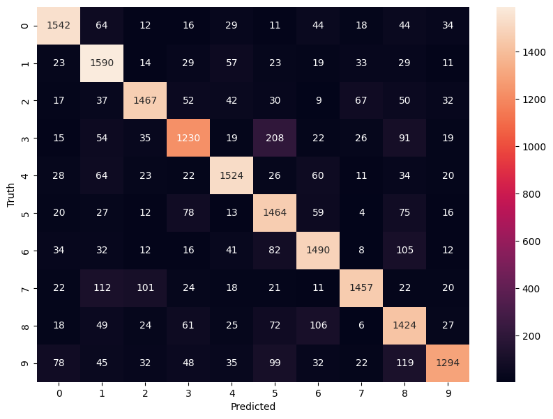

```python
# create model
hf_model_5 = Sequential()
hf_model_5.add(Dense(128 , activation='relu', input_shape = (1024, )))
hf_model_5.add(Dense(64, activation='relu'))
hf_model_5.add(Dense(10, activation = 'softmax'))

# Compile the model
sgd = optimizers.SGD(lr = 0.01)
hf_model_5.compile(optimizer = sgd, loss=losses.categorical_crossentropy, metrics=['accuracy'])

history = hf_model_5.fit(X_train, y_train_cat, validation_data=(X_valid, y_valid_cat), epochs=50, batch_size=32, verbose=0)

print_hf_report(history, hf_model_5)
```